# EDA-challenge.Rmd

2024-02-17

Keerthi Stanley

Load data into r

```r
library(tidyverse)
f <- "https://raw.githubusercontent.com/difiore/ada-2024-datasets/main/data-wrangling.csv"
d <- read.table(f, header = TRUE, sep = ",", stringsAsFactors = FALSE)
```

1. create a new variable, BSD, which is the ratio of average male to female body mass

```r
d$BSD <- d$Body_mass_male_mean / d$Body_mass_female_mean
```

2. create a new variable named sex_ratio, which is the ratio of the number of adult females to adult males in a typical group

```r
d$sex_ratio <- d$AdultFemale / d$AdultMales
```

3. create a new variable named DI (for “defensibility index”), which is the ratio of day range length to the diameter of the home range

diameter of homerange:

- presume homerange is the circle’s area, what is the diameter?

AREA = A = pi*(r^2) . The variable pi (note, without parentheses) will return the value of as a constant built-in to R, and the function sqrt() can be used to calculate the square root ()

diameter = 2*r r = sqrt(Area/pi) = sqrt(HomeRange_km2/pi)

thus the diameter of homerange = 2*r = 2*(sqrt(HomeRange_km2/pi))

but remember to draw HomeRange_km2 from the dataset using d$

```r
d$DI <- d$DayLength_km / (2 * sqrt(d$HomeRange_km2/pi))
```

4. Plot the relationship between day range length and time spent moving, for these primate species overall and by family.

In the table we see that: DayLength_km = day range length (y) Move = time spent moving (x)

without any transformations:

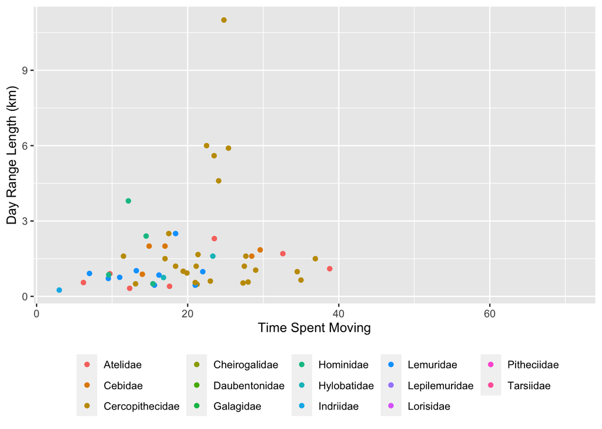

```r
# plot object and color points by Family
p <- ggplot(data = d, aes(x = Move, y = DayLength_km,
    color = factor(Family)))

# axis labels
p <- p + xlab("Time Spent Moving") + ylab("Day Range Length (km)")
# make a scatterplot, omit missing data with na.rm
p <- p + geom_point(na.rm = TRUE)
# modify legend
p <- p + theme(legend.position = "bottom", legend.title = element_blank())

p
```

the plot above WIHTOUT a transformation does not give us the best representation of the data, the points are too clustered in one area. so we will replot with a Log transformation

Log transformation:

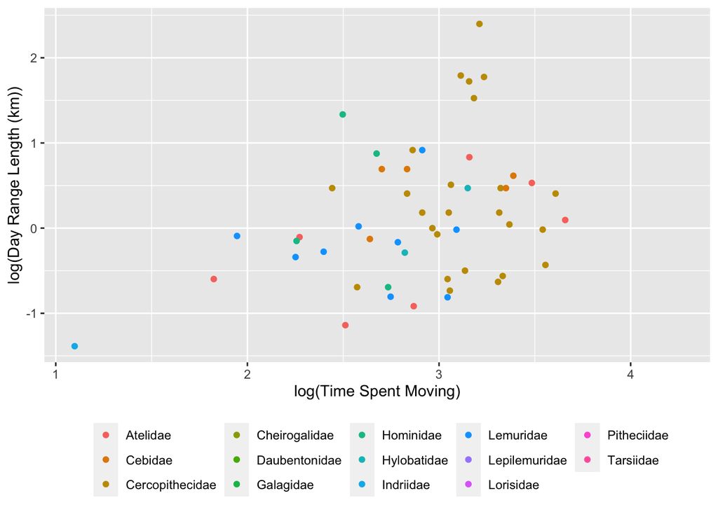

```r
# plot object and color points by Family
p <- ggplot(data = d, aes(x = log(Move), y = log(DayLength_km),
    color = factor(Family)))

# axis labels
p <- p + xlab("log(Time Spent Moving)") + ylab("log(Day Range Length (km))")
# make a scatterplot, omit missing data with na.rm
p <- p + geom_point(na.rm = TRUE)
# modify legend
p <- p + theme(legend.position = "bottom", legend.title = element_blank())

p
```

QUESTIONS: Do species that spend more time moving travel farther overall? - no, the scatter plot does not show a clear positive linear slope that would indicate that species that spend more time moving also travel further

How about within any particular primate family? - no even within each family there is not a clear trend correlating more time moving to farther distance traveled

Should you transform either of these variables? - yes, as shown above, the log transformation of x and y gives us a much more normal data distribution

5. Plot the relationship between day range length and group size, overall and by family.

WITHOUT TRANSFORMATION:

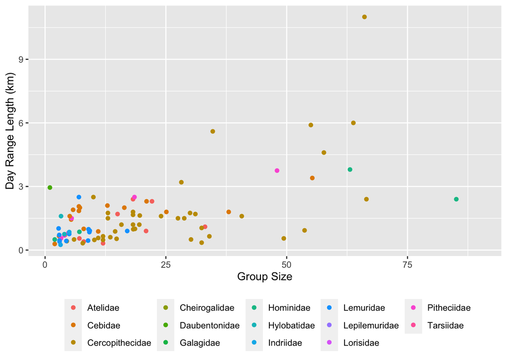

```r
# plot object and color points by Family
p <- ggplot(data = d, aes(x = MeanGroupSize, y = DayLength_km,
    color = factor(Family)))

# axis labels
p <- p + xlab("Group Size") + ylab("Day Range Length (km)")
# make a scatterplot, omit missing data with na.rm
p <- p + geom_point(na.rm = TRUE)
# modify legend
p <- p + theme(legend.position = "bottom", legend.title = element_blank())

p
```

Log Transformation:

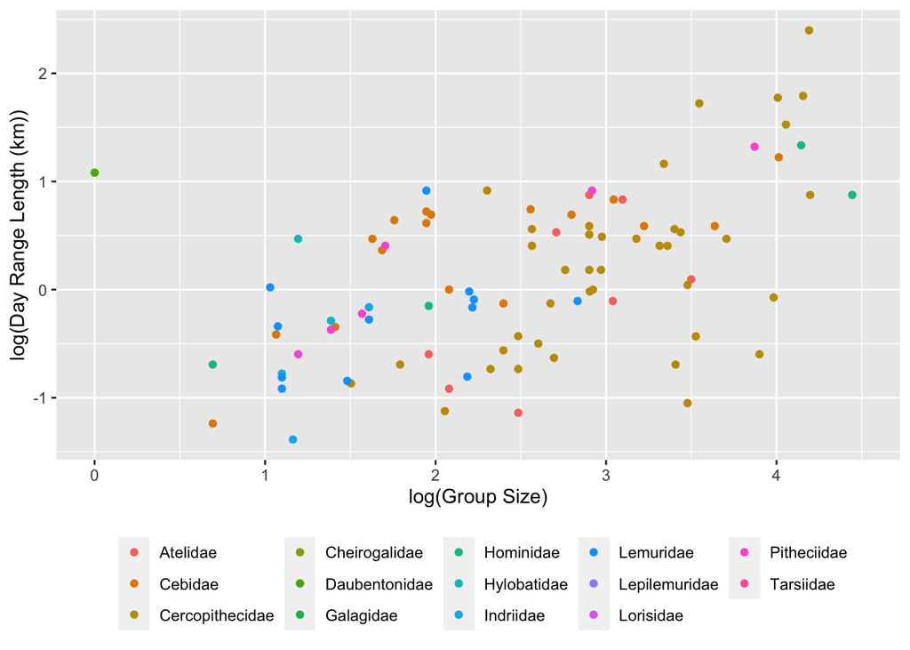

```r
p <- ggplot(data = d, aes(x = log(MeanGroupSize), y = log(DayLength_km),
    color = factor(Family)))  # plot object and color points by Family

# axis labels
p <- p + xlab("log(Group Size)") + ylab("log(Day Range Length (km))")
# make a scatterplot, omit missing data with na.rm
p <- p + geom_point(na.rm = TRUE)
# modify legend
p <- p + theme(legend.position = "bottom", legend.title = element_blank())

p
```

Should you transform either of these variables? - Once again the log transformation of both variables allows us to best visualize the data

6. Plot the relationship between body size dimorphism and canine size dimorphism overall and by family.

BSD = body size dimorphism Canine_Dimorphism = canine dimorphism

using the log transformation for this as well, as it best visualizes the data:

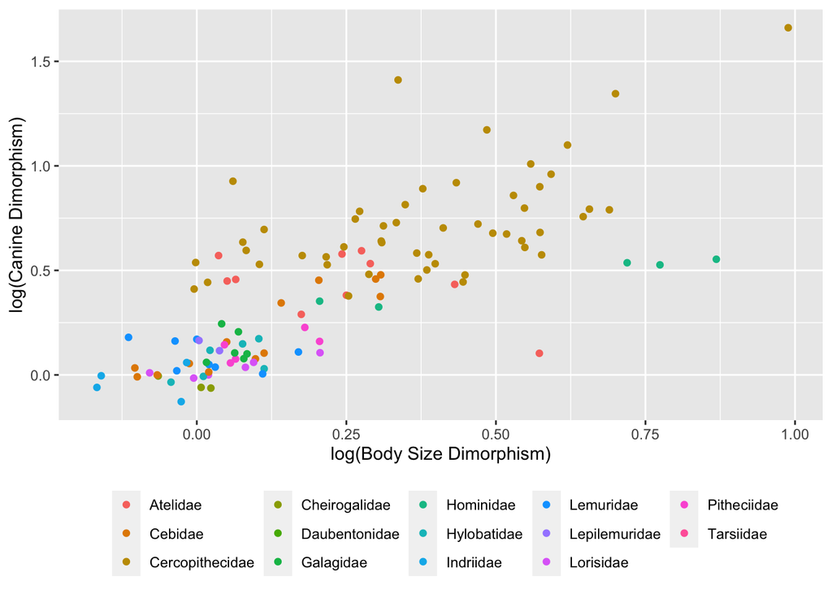

```r
p <- ggplot(data = d, aes(x = log(BSD), y = log(Canine_Dimorphism),
    color = factor(Family)))  # plot object and color points by Family

# modify the axis labels
p <- p + xlab("log(Body Size Dimorphism)") + ylab("log(Canine Dimorphism)")
# then we make a scatterplot, omit missing data with na.rm
p <- p + geom_point(na.rm = TRUE)
# then we modify the legend
p <- p + theme(legend.position = "bottom", legend.title = element_blank())
# and, finally, we plot the object
p
```

QUESTIONS: Do taxa with greater size dimorphism also show greater canine dimorphism? - yes! we do tend to see a more positive linear trend here OVERALL throughout families

7. Create a new variable named diet_strategy that is “frugivore” if fruits make up >50% of the diet, “folivore” if leaves make up >50% of the diet, and “omnnivore” if neither of these is true. Then, do boxplots of group size for species with different dietary strategies.

1st- create new variable diet_strategy –> use mutate()

2nd- use conditional expression –> in this case case_when() because we are dealing with multiple “if” statements

- here I’m using the pipe operator to join the two functions

```r
# modify dataset d
# mutate()- adds column titled 'diet_strategy'
d <- d %>%
  mutate(diet_strategy = case_when(
    Fruit > 50 ~ "frugivore",
    Leaves > 50 ~ "folivore",
    TRUE ~ "omnivore" #basically applies to all data that doesn't fit into the original 2 criteria/cases mentioned
  )
  )
```

Now time to make the BOXPLOTS for this data (x= species with same diet strategy, y= group size):

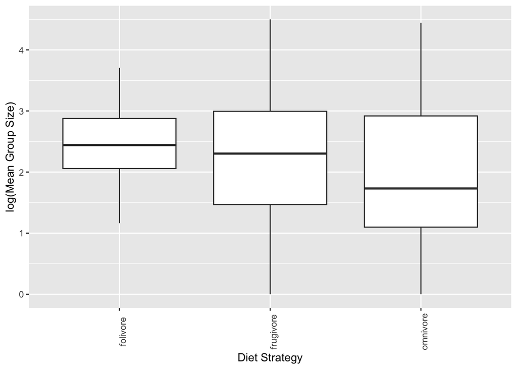

```r
p <- ggplot(data = d, aes(x = diet_strategy, y = log(MeanGroupSize)))
p <- p + geom_boxplot(na.rm = TRUE) #plot boxplot and omit missing data
p <- p + theme(axis.text.x = element_text(angle = 90))
p <- p + ylab("log(Mean Group Size)")
p <- p + xlab("Diet Strategy")
p
```

8. In one line of code, using {dplyr} verbs and the forward pipe (%>%) operator, do the following:
1. Add a variable, Binomial to the data frame d, which is a concatenation of the Genus and Species…
- same process as before with mutate()
  2. Trim the data frame to only include the variables Binomial, Family, Brain_size_species_mean, and Body_mass_male_mean
- use select() from dplyr
  3. Group these variables by Family
- use group_by() from dplyr
  4. Calculate the average value for Brain_size_species_mean and Body_mass_male_mean per Family (remember, you may need to specify na.rm = TRUE)
- use summarize()
  5. arrange by increasing average brain size
- use arrange()

```r
# the isntructions said to make these changes to dataset d, but I didn't want to alter the original changes to the dataset made from the previous problems, so I created the new dataset, d2

# if you want to directly change d, then change d2 to d below
d2 <- d %>%
  # first let's add/mutate in the new variable Binomial
  mutate(Binomial = paste(Genus, Species, sep = " ")) %>%
  # select only the variables we want to still include (listed above)
  select(Binomial, Family, Brain_Size_Species_Mean, Body_mass_male_mean) %>%

  # NOTE!! - if you want "Binomial" to be represented in the dataset then stop at line 224 and remove the pipe operator!

  # group by Family from dataset d
  group_by(Family) %>%
  #calculate averages for brain size and male body mass
  summarize(avgBrainSize = mean(Brain_Size_Species_Mean, na.rm = TRUE),
    avgMale_BodyMass = mean(Body_mass_male_mean, na.rm = TRUE)) %>%
  #arrange by increasing average brain size
  arrange(avgBrainSize)
```